# GOV321 - Day 0 Answer Key

#### British Election Study (BES)

This section follows code examples in Chapter 3. Read in the British Election Study (BES) data and examine it, what are the data types, which data is missing, etc.?

```r
bes<-read.csv('BES.csv')

# examine the data --
head(bes)
```

```
##         vote leave education age
## 1      leave     1         3  60
## 2      leave     1        NA  56
## 3       stay     0         5  73
## 4      leave     1         4  64
## 5 don't know    NA         2  68
## 6       stay     0         4  85
```

```r
str(bes)
```

```
## 'data.frame':    30895 obs. of  4 variables:
##  $ vote     : chr  "leave" "leave" "stay" "leave" ...
##  $ leave    : int  1 1 0 1 NA 0 1 1 1 1 ...
##  $ education: int  3 NA 5 4 2 4 3 2 3 4 ...
##  $ age      : int  60 56 73 64 68 85 78 51 59 68 ...
```

Check rows containing missing data:

```r
dim(bes[is.na(bes),])
```

```
## [1] 6276    4
```

#### Exercise

##### 1. Which variables contain missing values?

Education, leave (‘don’t know’ are not coded)

```r
names(bes)
```

```
## [1] "vote"      "leave"     "education" "age"
```

```r
dim(bes[is.na(bes$vote),])
```

```
## [1] 0 4
```

```r
dim(bes[is.na(bes$leave),])
```

```
## [1] 2851    4
```

```r
dim(bes[is.na(bes$education),])
```

```
## [1] 3425    4
```

```r
dim(bes[is.na(bes$age),])
```

```
## [1] 0 4
```

##### 3. What is the percentage of respondents who answered ‘leave’?

44.3%

```r
prop.table(table(bes$vote))
```

```
##
## don't know      leave       stay won't vote
## 0.07489885 0.44317851 0.46454119 0.01738145
```

##### 4. What is the percentage of respondents who answered ‘don’t know’?

7.4%

##### 5. Plot the distribution of answers in the ‘vote’ column

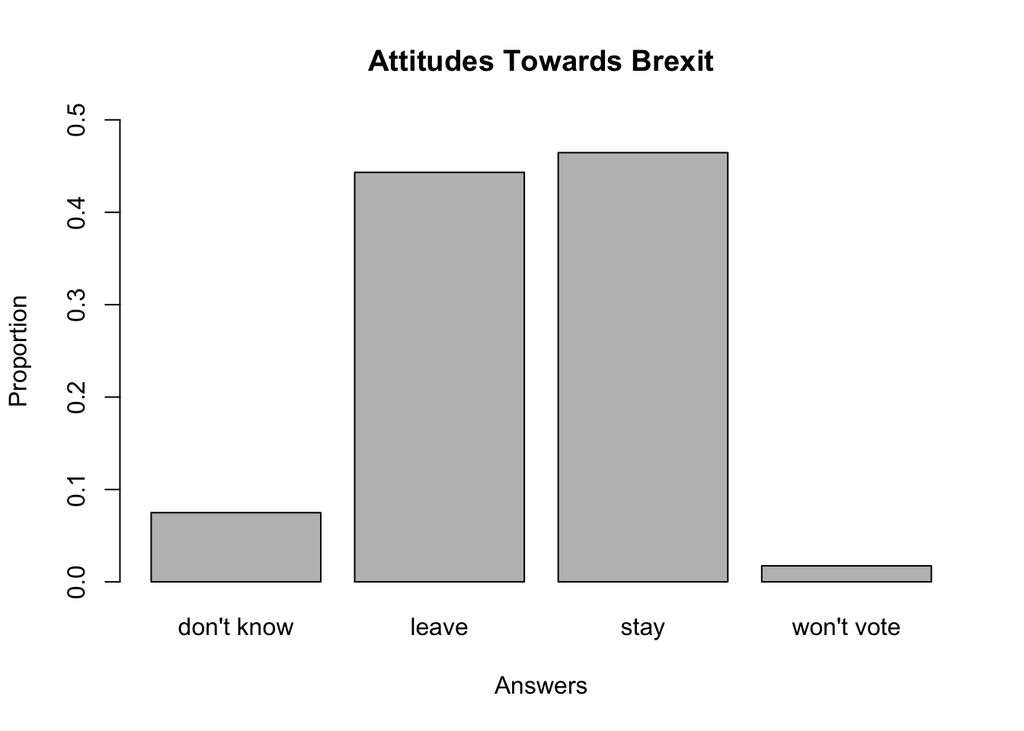

```r
barplot(prop.table(table(bes$vote)), ylim=c(0,0.5), xlab="Answers", ylab='Proportion',
        main="Attitudes Towards Brexit")
```

##### 6. What is the average age of the respondents

50.7

```r
mean(bes$age)
```

```
## [1] 50.75025
```

##### 7. What percent of respondents in the data set are over 60? (tip: Use logical operators `>, <, ==, !=, <=, >=`)

34%

```r
dim(bes[bes$age > 60,])[1]/dim(bes)[1]
```

```
## [1] 0.34067
```

##### 8. What percent of respondents in the data set are exactly 60 years old?

2.4%

```r
dim(bes[bes$age == 60,])[1]/dim(bes)[1]
```

```
## [1] 0.02401683
```

##### 9. What percent of respondents in the data set are NOT 60 years old?

97.5%

```r
dim(bes[bes$age != 60,])[1]/dim(bes)[1]
```

```
## [1] 0.9759832
```

##### 10. What is the distribution of age? Do you notice anything? (tip: use `hist()` and `boxplot()`)

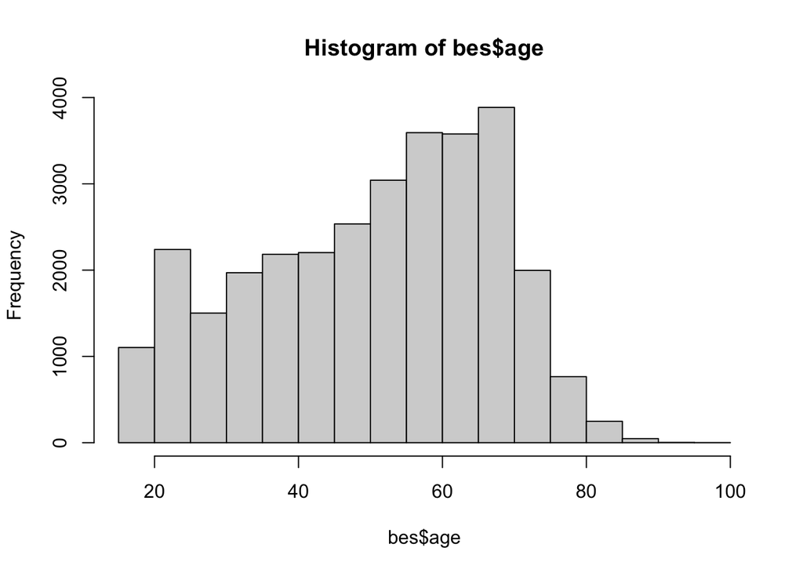

```r
hist(bes$age)
```

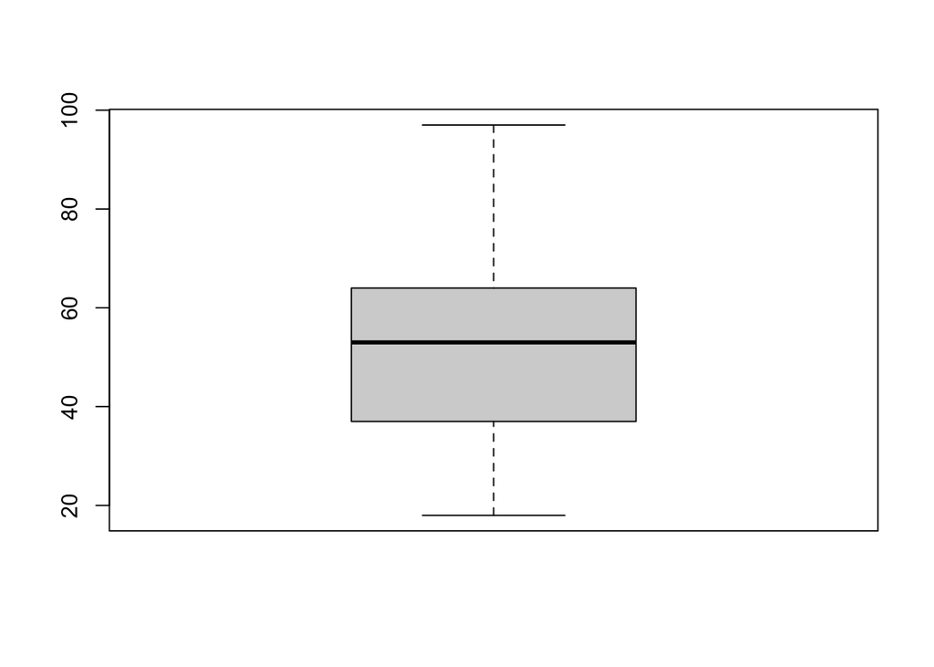

```r
boxplot(bes$age)
```

##### 11. Examine distribution of age of brexit supporters and non-supporters. What do you notice?

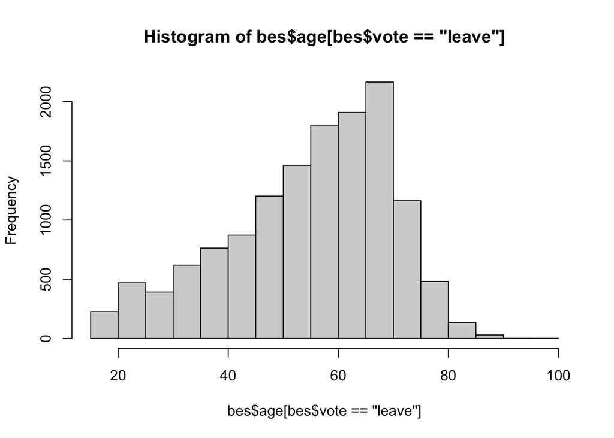

```r
hist(bes$age[bes$vote == 'leave'])
```

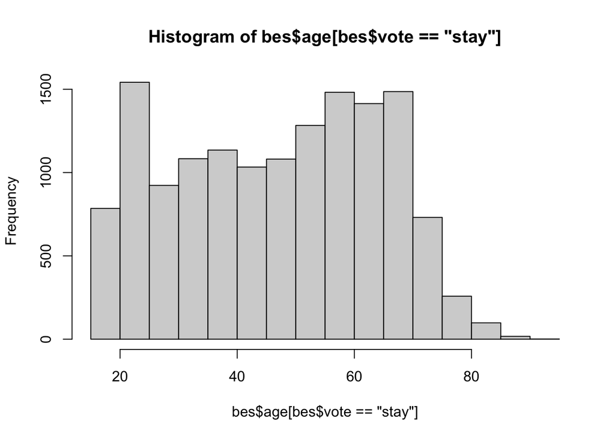

```r
hist(bes$age[bes$vote == 'stay'])
```

##### 12. Check distribution of brexit non-supporters by education levels

(tip: first use `na.omit()` because education variable contains NAs; second, create a dummy variable 1 indicating ‘leave’, 0 for rest; third, use prop.table to see a two-way proportions table)

```r
bes1<-na.omit(bes)
dim(bes1)
```

```
## [1] 25097     4
```

```r
dim(bes1[complete.cases(bes1),])
```

```
## [1] 25097     4
```

```r
bes1$leave<-ifelse(bes1$vote=='leave',1,0)
head(bes1)
```

```
##    vote leave education age
## 1 leave     1         3  60
## 3  stay     0         5  73
## 4 leave     1         4  64
## 6  stay     0         4  85
## 7 leave     1         3  78
## 8 leave     1         2  51
```

```r
prop.table(table(bes1$leave, bes1$education))
```

```
##
##              1          2          3          4          5
##   0 0.01984301 0.07024744 0.12009404 0.24229988 0.07562657
##   1 0.05403036 0.13499621 0.10698490 0.15073515 0.02514245
```